# head02 (B46) — Profil, Kalibrierung und der gemeinsame Anteil

60-m- und 10-m-Kette in Schnee, 13.01.–02.02.2026, vier Telegramme am Tag

Author

Thom Laepple

Published

September 24, 2026

**head02** stand an **B46** mit zwei verfüllten Bohrlöchern — einer **60-m-Kette** und einer **10-m-Kette** — sowie einem Lufttemperatursensor in 2 m Höhe. Übertragen werden je Knoten **NTC1, GND und Druck**, dazu Zeit, Platinentemperatur und Batteriespannung; ein NTC2 oder Referenzwiderstand fehlt. Der Kopf sendete **alle vier Stunden** und ist am 02.02.2026 ausgefallen — die Analyse des Ausfalls steht in `head02_ausfall.qmd`, hier geht es um die Messungen davor.

```r
library(readr); library(dplyr); library(tidyr); library(ggplot2); library(patchwork)
source("../Greenland2026/decode_core.R")

BLUE <- "#2a78d6"; ORANGE <- "#eb6834"; AQUA <- "#1baf7a"

raw <- read_csv("./data/messages-1781290180297_old.csv", show_col_types = FALSE) |>
  filter(grepl("231708", Device)) |>
  transmute(recv = lubridate::dmy_hms(`Date Time (UTC)`, tz = "UTC"),
            nb = `Length (Bytes)`, hex = tolower(Payload)) |>
  filter(nb == 209, !grepl("6f6f", hex),
         recv < as.POSIXct("2026-02-02 17:13", tz = "UTC")) |>
  arrange(recv)

s_int <- function(h) { v <- strtoi(h, 16L); n <- nchar(h)/2
                       ifelse(v >= 2^(8*n-1), v - 2^(8*n), v) }

# 209 B = 4 B Zeit + 3 B ADC + 25 x (NTC1 3 B, GND 2 B, Druck 3 B) + 2 B Batterie
head_ch <- raw |> mutate(
  adc_C = 6.101e-5 * strtoi(substr(hex, 9, 14), 16L) - 256.6,
  batt  = strtoi(substr(hex, nchar(hex) - 3, nchar(hex)), 16L),
  hr    = as.integer(format(recv, "%H"))) |>
  filter(adc_C > -50, adc_C < -35)            # fünf Ausreißer des Platinenkanals raus

nodes <- bind_rows(lapply(seq_len(nrow(head_ch)), function(i) {
  h <- head_ch$hex[i]
  data.frame(recv = head_ch$recv[i], position = 1:25,
    counts = s_int(substring(h, seq(15, by = 16, length.out = 25),
                                seq(20, by = 16, length.out = 25))),
    gnd = s_int(substring(h, seq(21, by = 16, length.out = 25),
                             seq(24, by = 16, length.out = 25))),
    p_hPa = strtoi(substring(h, seq(25, by = 16, length.out = 25),
                                seq(30, by = 16, length.out = 25)), 16L) / 1000) }))

dmap  <- read_csv("./data/head02_depths.csv", show_col_types = FALSE)
nodes <- nodes |> left_join(dmap, by = "position")
```

Ausgewertet werden 79 Telegramme von 18.01. bis 02.02.2026.

## Knoten, Tiefen, Kalibrierung

Die Abfragereihenfolge und die Einbautiefen stehen in `data/head02_depths.csv`. Für die Kalibrierung wird die **Calibration Registry** genutzt, Batch `kohnen2526` (cal_id `2025-11_vorKohnen`); wo kein Eintrag vorliegt, greift die universelle Mean-S4-Kurve.

```r
CALIB_REG <- "/Users/tlaepple/sharedAI/CalibrationRegistry"
reg_ok <- file.exists(file.path(CALIB_REG, "R/calib_registry.R"))
if (reg_ok) {
  Sys.setenv(CALIB_REGISTRY = file.path(CALIB_REG, "calibrations.csv"))
  source(file.path(CALIB_REG, "R/calib_registry.R"))
}

cal_one <- function(counts, node) {
  key <- paste0(node, "_NTC1")
  if (!reg_ok) return(list(T = NTC_mean(counts), src = "Mean-S4"))
  tryCatch(list(T = calib_T(counts, key, batch = "kohnen2526"), src = "Registry"),
           error = function(e) list(T = NTC_mean(counts), src = "Mean-S4"))
}

nodes <- nodes |> group_by(position) |> group_modify(function(g, k) {
  nd <- dmap$node[dmap$position == k$position]
  r  <- cal_one(g$counts, nd)
  g$T <- r$T; g$T_mean <- NTC_mean(g$counts); g$src <- r$src; g }) |> ungroup()

knitr::kable(
  nodes |> group_by(position, node, depth_m, chain, src) |>
    summarise(`T (°C)` = round(mean(T), 2),
              `Mean-S4 (°C)` = round(mean(T_mean), 2),
              `Differenz (K)` = round(mean(T - T_mean), 3), .groups = "drop") |>
    arrange(position) |>
    rename(Pos = position, Node = node, `Tiefe (m)` = depth_m, Kette = chain, Quelle = src),
  caption = "Knotenliste mit Kalibrierquelle. Zeitmittel über den ausgewerteten Zeitraum.")
```

Knotenliste mit Kalibrierquelle. Zeitmittel über den ausgewerteten Zeitraum.

| Pos | Node | Tiefe (m) | Kette | Quelle | T (°C) | Mean-S4 (°C) | Differenz (K) |
| --- | --- | --- | --- | --- | --- | --- | --- |
| 1 | N21 | -2.0 | Luft | Mean-S4 | -24.21 | -24.21 | 0.000 |
| 2 | N23 | 5.0 | 60m-Kette | Registry | -41.64 | -41.63 | -0.013 |
| 3 | N00 | 8.0 | 60m-Kette | Registry | -40.38 | -40.48 | 0.105 |
| 4 | N01 | 10.0 | 60m-Kette | Registry | -40.27 | -40.34 | 0.067 |
| 5 | N02 | 13.0 | 60m-Kette | Registry | -40.25 | -40.32 | 0.075 |
| 6 | N03 | 16.0 | 60m-Kette | Registry | -40.36 | -40.44 | 0.087 |
| 7 | N04 | 21.0 | 60m-Kette | Registry | -40.56 | -40.67 | 0.107 |
| 8 | N06 | 26.0 | 60m-Kette | Registry | -40.68 | -40.74 | 0.060 |
| 9 | N07 | 32.0 | 60m-Kette | Registry | -40.76 | -40.78 | 0.022 |
| 10 | N11 | 40.0 | 60m-Kette | Registry | -40.83 | -40.81 | -0.017 |
| 11 | N12 | 50.0 | 60m-Kette | Registry | -40.88 | -40.98 | 0.096 |
| 12 | N60 | 62.0 | 60m-Kette | Registry | -40.92 | -40.98 | 0.058 |
| 13 | N22 | 0.2 | 10m-Kette | Registry | -23.67 | -23.69 | 0.019 |
| 14 | N79 | 0.5 | 10m-Kette | Registry | -25.26 | -25.35 | 0.089 |
| 15 | N80 | 1.0 | 10m-Kette | Registry | -28.09 | -28.12 | 0.038 |
| 16 | N81 | 1.5 | 10m-Kette | Registry | -30.72 | -30.74 | 0.018 |
| 17 | N82 | 2.0 | 10m-Kette | Registry | -33.14 | -33.24 | 0.100 |
| 18 | N83 | 3.0 | 10m-Kette | Registry | -36.83 | -36.94 | 0.113 |
| 19 | N84 | 4.0 | 10m-Kette | Registry | -38.84 | -38.91 | 0.068 |
| 20 | N85 | 5.0 | 10m-Kette | Registry | -39.96 | -40.00 | 0.040 |
| 21 | N86 | 6.0 | 10m-Kette | Registry | -40.42 | -40.48 | 0.069 |
| 22 | N88 | 7.0 | 10m-Kette | Registry | -40.55 | -40.61 | 0.068 |
| 23 | N89 | 8.0 | 10m-Kette | Registry | -40.53 | -40.62 | 0.085 |
| 24 | N90 | 9.0 | 10m-Kette | Registry | -40.47 | -40.55 | 0.083 |
| 25 | N91 | 10.0 | 10m-Kette | Registry | -40.42 | -40.49 | 0.075 |

24 der 25 Knoten haben eine Lab-Kalibrierung in der Registry; es fehlt allein **N21**, der Lufttemperatursensor. Die Registry-Werte weichen von der Mean-S4-Kurve um höchstens 0,11 K ab — die universelle Kurve trifft diese Sensoren also gut, und der Absolutwert der Kette ändert sich durch die Kalibrierung nur wenig.

## Tiefenprofil

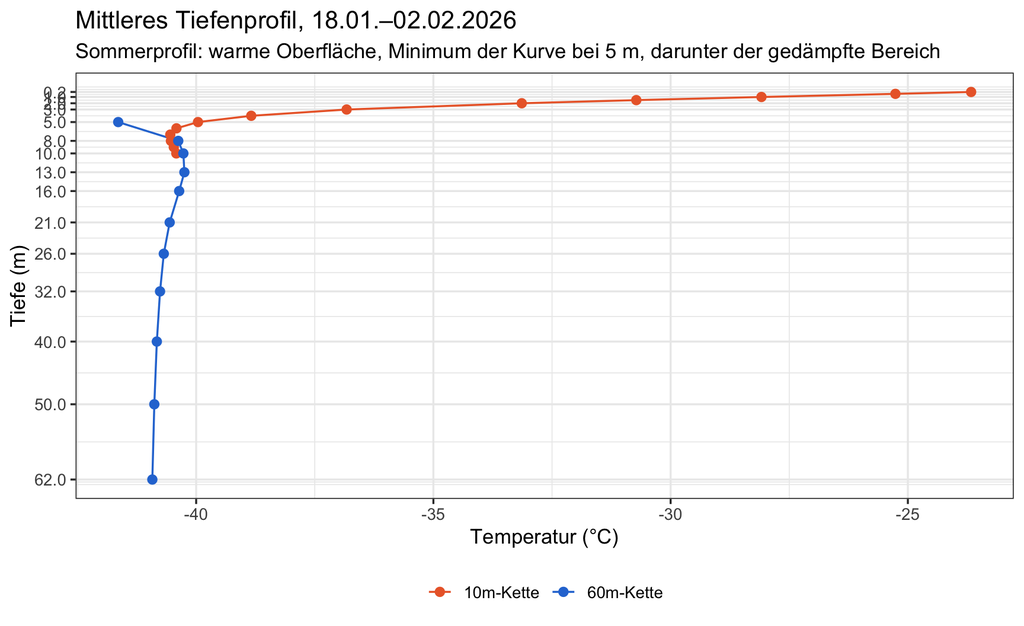

```r
prof <- nodes |> filter(chain != "Luft") |> group_by(chain, depth_m) |>
  summarise(T = mean(T), .groups = "drop")

ggplot(prof, aes(T, depth_m, colour = chain)) +
  geom_path(linewidth = 0.6) + geom_point(size = 2.4) +
  scale_y_reverse(name = "Tiefe (m)", breaks = c(0.2, 1, 2, 3, 5, 8, 10, 13, 16, 21, 26, 32, 40, 50, 62)) +
  scale_x_continuous(name = "Temperatur (°C)") +
  scale_colour_manual(values = c("60m-Kette" = BLUE, "10m-Kette" = ORANGE), name = NULL) +
  labs(title = "Mittleres Tiefenprofil, 18.01.–02.02.2026",
       subtitle = "Sommerprofil: warme Oberfläche, Minimum der Kurve bei 5 m, darunter der gedämpfte Bereich") +
  theme_bw(base_size = 13) + theme(legend.position = "bottom")
```

```r
knitr::kable(
  prof |> filter(depth_m %in% c(5, 8, 10)) |>
    pivot_wider(names_from = chain, values_from = T) |>
    transmute(`Tiefe (m)` = depth_m,
              `60m-Kette (°C)` = round(`60m-Kette`, 2),
              `10m-Kette (°C)` = round(`10m-Kette`, 2),
              `Differenz (K)` = round(`60m-Kette` - `10m-Kette`, 2)),
  caption = "Gleiche Tiefe in beiden Bohrlöchern.")
```

Gleiche Tiefe in beiden Bohrlöchern.

| Tiefe (m) | 60m-Kette (°C) | 10m-Kette (°C) | Differenz (K) |
| --- | --- | --- | --- |
| 5 | -41.64 | -39.96 | -1.68 |
| 8 | -40.38 | -40.53 | 0.15 |
| 10 | -40.27 | -40.42 | 0.15 |

Bei 8 und 10 m stimmen die beiden Bohrlöcher auf rund 0,1 K überein. Der 5-m-Knoten der 60-m-Kette (N23) liegt 1,7 K daneben — er ist als einziger vom Typ **PM**, alle anderen sind MM; die Abweichung ist eine Eigenschaft dieses Sensortyps, nicht des Bohrlochs.

Der gedämpfte Bereich liegt bei **−40,3 bis −41,0 °C**. Das ist rund 3,5 K wärmer als der Wert, den head04 an B40 zeigt; ob das ein Standortunterschied ist, gehört zusammen mit dem Vergleich B50/B40 (`vergleich_b50_b40.qmd`) geprüft.

## Zeitreihen

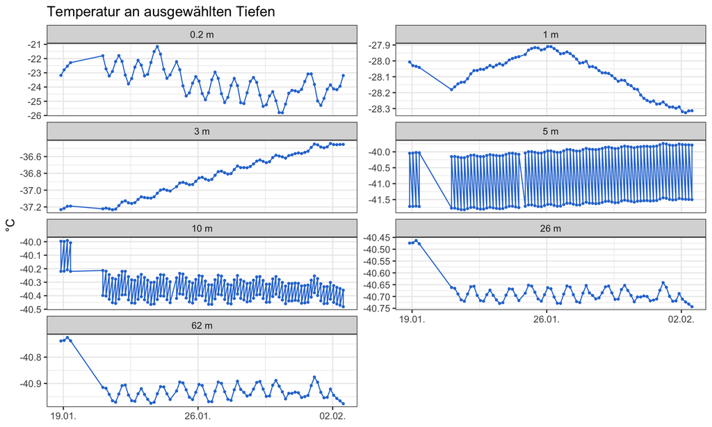

```r
sel <- c(0.2, 1, 3, 5, 10, 26, 62)
nodes |> filter(depth_m %in% sel, chain != "Luft") |>
  mutate(lab = factor(sprintf("%s m", depth_m), levels = sprintf("%s m", sel))) |>
  ggplot(aes(recv, T)) +
  geom_line(colour = BLUE, linewidth = 0.5) + geom_point(colour = BLUE, size = 0.8) +
  facet_wrap(~ lab, scales = "free_y", ncol = 2) +
  scale_x_datetime(date_labels = "%d.%m.") +
  labs(title = "Temperatur an ausgewählten Tiefen", x = NULL, y = "°C") +
  theme_bw(base_size = 12)
```

Die vierstündliche Abtastung löst in den obersten Metern den Tagesgang auf — im antarktischen Januar bei Polartag ist er flach, aber vorhanden.

## Der gemeinsame Anteil

Für die Auswertung auf mK-Niveau ist der wichtigste Befund dieser Reihe, dass sich die Residuen aller Knoten **gemeinsam** bewegen.

```r
# Ab 20.01.: davor liegt die Platinentemperatur 2,5 K tiefer (anderer Zustand), und am
# 19.01. fiel die Kette für acht Stunden aus (siehe head02_ausfall.qmd).
STABLE <- as.POSIXct("2026-01-20", tz = "UTC")
nodes_s <- nodes |> filter(recv >= STABLE)
head_s  <- head_ch |> filter(recv >= STABLE)

deep_pos <- dmap$position[dmap$chain == "60m-Kette" & dmap$depth_m >= 13]
tms  <- sort(unique(nodes_s$recv))
td   <- as.numeric(difftime(tms, min(tms), units = "days"))

R <- sapply(sort(unique(nodes_s$position)), function(p) {
  z <- nodes_s |> filter(position == p) |> arrange(recv)
  resid(loess(z$T ~ td, span = 0.4)) * 1000 })      # Residuum in mK
colnames(R) <- sort(unique(nodes_s$position))
Rd <- R[, as.character(deep_pos)]
CM <- rowMeans(Rd)

knitr::kable(data.frame(
  Größe = c("Streuung je Knoten (tiefe Knoten)", "Streuung des gemeinsamen Anteils",
            "Streuung nach dessen Abzug", "mittlere Korrelation zwischen den Knoten"),
  Wert = c(sprintf("%.1f mK", mean(apply(Rd, 2, sd))), sprintf("%.1f mK", sd(CM)),
           sprintf("%.1f mK", mean(apply(Rd - CM, 2, sd))),
           sprintf("%.2f", mean(cor(Rd)[upper.tri(cor(Rd))])))),
  row.names = FALSE, caption = "Knoten 13–62 m der 60-m-Kette.")
```

Knoten 13–62 m der 60-m-Kette.

| Größe | Wert |
| --- | --- |
| Streuung je Knoten (tiefe Knoten) | 22.5 mK |
| Streuung des gemeinsamen Anteils | 22.5 mK |
| Streuung nach dessen Abzug | 0.1 mK |
| mittlere Korrelation zwischen den Knoten | 1.00 |

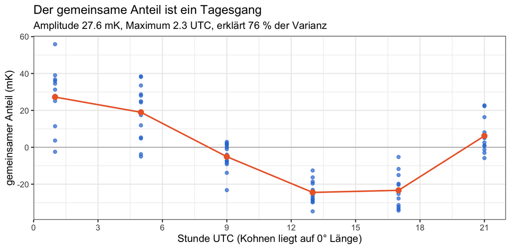

```r
cm_df <- data.frame(recv = tms, cm = CM, hr = as.integer(format(tms, "%H")))
hfit  <- lm(cm ~ cos(2*pi*hr/24) + sin(2*pi*hr/24), data = cm_df)
amp   <- unname(sqrt(sum(coef(hfit)[2:3]^2)))
phase <- unname((atan2(coef(hfit)[3], coef(hfit)[2]) * 12/pi) %% 24)

ggplot(cm_df, aes(hr, cm)) +
  geom_hline(yintercept = 0, colour = "grey70") +
  geom_point(size = 1.8, colour = BLUE, alpha = 0.7) +
  stat_summary(fun = mean, geom = "line", colour = ORANGE, linewidth = 0.9) +
  stat_summary(fun = mean, geom = "point", colour = ORANGE, size = 3) +
  scale_x_continuous(breaks = seq(0, 21, 3), name = "Stunde UTC (Kohnen liegt auf 0° Länge)") +
  labs(title = "Der gemeinsame Anteil ist ein Tagesgang",
       subtitle = sprintf("Amplitude %.1f mK, Maximum %.1f UTC, erklärt %.0f %% der Varianz",
                          amp, phase, 100*summary(hfit)$r.squared),
       y = "gemeinsamer Anteil (mK)") +
  theme_bw(base_size = 13)
```

**Die Elektronik ist es nicht.** Der Kopf liegt 8–10 m tief im Firn; dort gibt es keinen Tagesgang, und die Hauskanäle bestätigen das.

```r
diu <- function(v, hr) { f <- lm(v ~ cos(2*pi*hr/24) + sin(2*pi*hr/24))
  c(amp = unname(sqrt(sum(coef(f)[2:3]^2))),
    max = unname((atan2(coef(f)[3], coef(f)[2]) * 12/pi) %% 24),
    r2  = summary(f)$r.squared) }
td_h  <- as.numeric(difftime(head_s$recv, min(head_s$recv), units = "days"))
d_adc <- diu(resid(loess(head_s$adc_C ~ td_h, span = 0.4)) * 1000, head_s$hr)
d_bat <- diu(resid(loess(head_s$batt  ~ td_h, span = 0.4)),        head_s$hr)
d_cm  <- diu(CM, cm_df$hr)

knitr::kable(data.frame(
  Kanal = c("NTC1, gemeinsamer Anteil", "Platinentemperatur", "Batteriespannung"),
  `Amplitude` = c(sprintf("%.1f mK", d_cm["amp"]), sprintf("%.0f mK", d_adc["amp"]),
                  sprintf("%.1f mV", d_bat["amp"])),
  `Maximum (UTC)` = round(c(d_cm["max"], d_adc["max"], d_bat["max"]), 1),
  `R²` = round(c(d_cm["r2"], d_adc["r2"], d_bat["r2"]), 2),
  `r mit dem gemeinsamen Anteil` = c("1.00", sprintf("%+.2f", cor(CM, head_s$adc_C)),
                                     sprintf("%+.2f", cor(CM, head_s$batt))),
  check.names = FALSE), row.names = FALSE,
  caption = "Nur die Knotenkanäle tragen den Tagesgang.")
```

Nur die Knotenkanäle tragen den Tagesgang.

| Kanal | Amplitude | Maximum (UTC) | R² | r mit dem gemeinsamen Anteil |
| --- | --- | --- | --- | --- |
| NTC1, gemeinsamer Anteil | 27.6 mK | 2.3 | 0.76 | 1.00 |
| Platinentemperatur | 40 mK | 0.6 | 0.03 | +0.06 |
| Batteriespannung | 6.8 mV | 12.3 | 0.06 | -0.09 |

**Es ist eine Verstärkungsänderung, kein Nullpunktfehler.** In der Temperatur sehen beide gleich aus, in den Rohcounts nicht: additiv verschiebt alle Knoten um denselben Betrag, multiplikativ proportional zum Messwert.

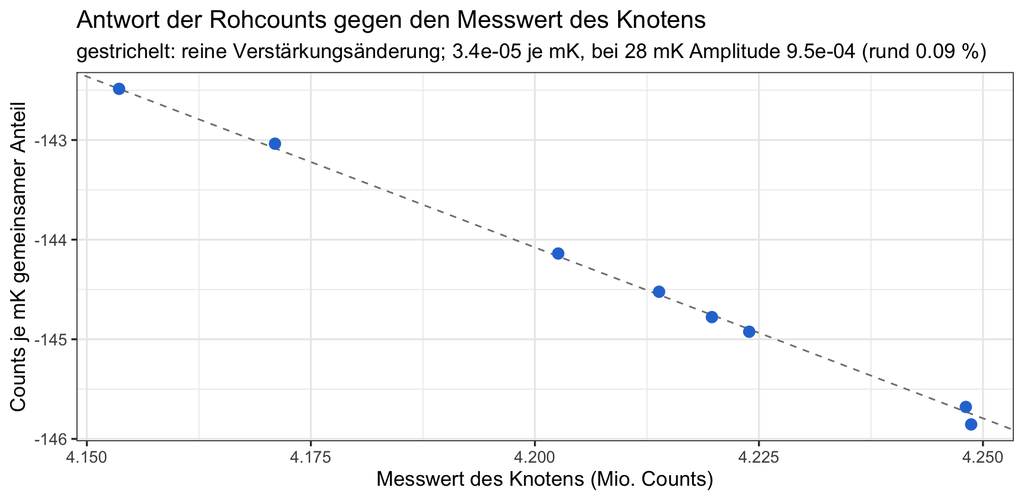

```r
rC <- sapply(deep_pos, function(p) {
  z <- nodes_s |> filter(position == p) |> arrange(recv)
  resid(loess(z$counts ~ td, span = 0.4)) })
lvl <- vapply(deep_pos, function(p) median(nodes_s$counts[nodes_s$position == p]), 0)
slp <- vapply(seq_along(deep_pos), function(i) unname(coef(lm(rC[, i] ~ CM))[2]), 0)
eps <- abs(mean(slp) / mean(lvl))

ggplot(data.frame(lvl = lvl/1e6, slp = slp), aes(lvl, slp)) +
  geom_abline(slope = -eps*1e6, intercept = 0, linetype = "dashed", colour = "grey50") +
  geom_point(size = 3, colour = BLUE) +
  labs(title = "Antwort der Rohcounts gegen den Messwert des Knotens",
       subtitle = sprintf("gestrichelt: reine Verstärkungsänderung; %.1e je mK, bei %.0f mK Amplitude %.1e (rund %.2f %%)",
                          eps, amp, eps*amp, 100*eps*amp),
       x = "Messwert des Knotens (Mio. Counts)", y = "Counts je mK gemeinsamer Anteil") +
  theme_bw(base_size = 13)
```

Der GND-Kanal passt dazu: bei rund −780 Counts müsste eine 0,1-%-Verstärkungsänderung dort 0,8 Counts ausmachen. Gemessen sind 0,77 Counts — die richtige Größe, bei 4 Counts Streuung aber nicht signifikant. **GND taugt damit nicht als Korrekturkanal**; ein mitgemessener Referenzwiderstand im selben Messpfad würde 0,1 % direkt erfassen und den Anteil abziehbar machen.

### Der gemeinsame Anteil folgt der Lufttemperatur

Der Kopf liegt zu tief für einen Tagesgang — aber der **Lufttemperatursensor** in 2 m Höhe sitzt an der Oberfläche, und sein Signal erklärt den gemeinsamen Anteil vollständig.

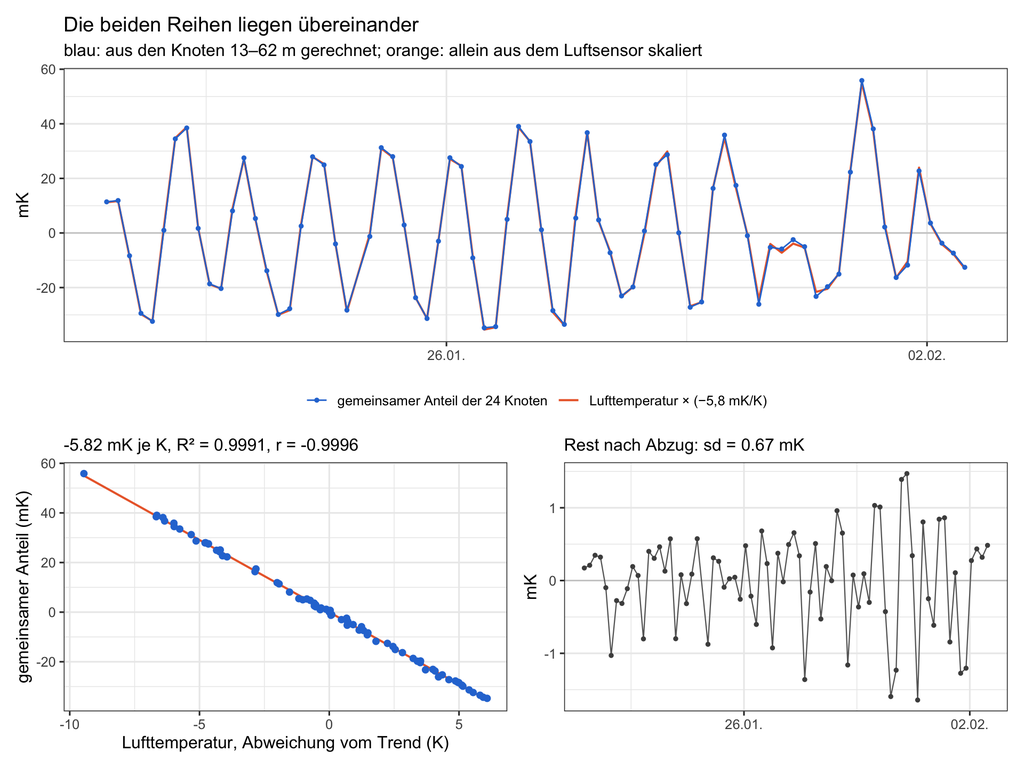

```r
air <- nodes_s |> filter(chain == "Luft") |> arrange(recv)
r_air <- resid(loess(air$T ~ td, span = 0.4))
fit_air <- lm(CM ~ r_air)

p_ts <- ggplot(data.frame(t = tms, cm = CM, sk = coef(fit_air)[2] * r_air)) +
  geom_hline(yintercept = 0, colour = "grey80") +
  geom_line(aes(t, sk, colour = "Lufttemperatur × (−5,8 mK/K)"), linewidth = 0.7) +
  geom_line(aes(t, cm, colour = "gemeinsamer Anteil der 24 Knoten"), linewidth = 0.5) +
  geom_point(aes(t, cm, colour = "gemeinsamer Anteil der 24 Knoten"), size = 1) +
  scale_colour_manual(values = c("gemeinsamer Anteil der 24 Knoten" = BLUE,
                                 "Lufttemperatur × (−5,8 mK/K)" = ORANGE), name = NULL) +
  scale_x_datetime(date_labels = "%d.%m.") +
  labs(title = "Die beiden Reihen liegen übereinander",
       subtitle = "blau: aus den Knoten 13–62 m gerechnet; orange: allein aus dem Luftsensor skaliert",
       x = NULL, y = "mK") +
  theme_bw(base_size = 12) + theme(legend.position = "bottom")

p_sc <- ggplot(data.frame(air = r_air, cm = CM), aes(air, cm)) +
  geom_smooth(method = "lm", se = FALSE, colour = ORANGE, linewidth = 0.7) +
  geom_point(size = 1.8, colour = BLUE) +
  labs(subtitle = sprintf("%.2f mK je K, R² = %.4f, r = %.4f",
                          coef(fit_air)[2], summary(fit_air)$r.squared, cor(CM, r_air)),
       x = "Lufttemperatur, Abweichung vom Trend (K)", y = "gemeinsamer Anteil (mK)") +
  theme_bw(base_size = 12)

p_res <- ggplot(data.frame(t = tms, r = resid(fit_air)), aes(t, r)) +
  geom_hline(yintercept = 0, colour = "grey80") +
  geom_line(colour = "grey40", linewidth = 0.4) + geom_point(size = 1, colour = "grey30") +
  scale_x_datetime(date_labels = "%d.%m.") +
  labs(subtitle = sprintf("Rest nach Abzug: sd = %.2f mK", sd(resid(fit_air))),
       x = NULL, y = "mK") +
  theme_bw(base_size = 12)

p_ts / (p_sc | p_res) + patchwork::plot_layout(heights = c(1.1, 1))
```

### Wo im Messpfad das ansetzt

Der Systemaufbau entscheidet, welche Erklärung möglich ist. Auf dem Sensorboard sitzen zwei NTC-Spannungsteiler und ein Referenzteiler mit Silizium-Sensor; die Signale werden **im Knoten gepuffert**, nur niederohmige Ausgänge gehen aufs Kabel. Zum Kopf laufen acht Adern: `Head_TxD`, `Head_RxD`, `Node IN`, `−0,3 V`, `GND`, `+3,3 V`, **`Vref`**, `GND`. Der ADC im Kopf misst **ratiometrisch gegen Vref**.

Damit gibt es genau einen Punkt, an dem eine Störung **alle** Kanäle gleichzeitig und proportional zu ihrem Messwert verschiebt: **Vref**. Jede Änderung dort geht als `counts → counts · (1 + δ)` in jeden Knoten ein, unabhängig davon, in welchem Bohrloch er hängt. Eine Störung auf der Analogleitung `Node IN` wirkte dagegen **additiv** — gleicher Betrag in Counts für alle Knoten. Die Daten trennen das:

```r
sel <- bind_rows(
  tibble(depth_m = c(1.5, 2, 3, 4, 6, 10), chain = "10m-Kette"),
  tibble(depth_m = c(13, 21, 32, 62),      chain = "60m-Kette"))

amv <- bind_rows(lapply(seq_len(nrow(sel)), function(i) {
  z <- nodes_s |> filter(depth_m == sel$depth_m[i], chain == sel$chain[i]) |> arrange(recv)
  r <- resid(loess(z$counts ~ td, span = 0.4))
  data.frame(depth_m = sel$depth_m[i], chain = sel$chain[i],
             lvl = median(z$counts), slope = unname(coef(lm(r ~ CM))[2])) }))
k_mult <- mean(amv$slope / amv$lvl); k_add <- mean(amv$slope)
amv <- amv |> mutate(mult = k_mult * lvl, add = k_add)

knitr::kable(amv |> transmute(`Tiefe (m)` = depth_m, Kette = chain,
    `Pegel (Mio. Counts)` = round(lvl/1e6, 2), `gemessen (Counts je mK)` = round(slope, 1),
    `multiplikativ erwartet` = round(mult, 1), `additiv erwartet` = round(add, 1)),
  row.names = FALSE,
  caption = sprintf("Antwort der Rohcounts über einen Pegelhub von %.0f %%. Reststreuung: multiplikativ %.1f Counts, additiv %.1f Counts.",
                    100*diff(range(amv$lvl))/mean(amv$lvl), sd(amv$slope - amv$mult), sd(amv$slope - amv$add)))
```

Antwort der Rohcounts über einen Pegelhub von 34 %. Reststreuung: multiplikativ 9.0 Counts, additiv 24.4 Counts.

| Tiefe (m) | Kette | Pegel (Mio. Counts) | gemessen (Counts je mK) | multiplikativ erwartet | additiv erwartet |
| --- | --- | --- | --- | --- | --- |
| 1.5 | 10m-Kette | 2.92 | -76.4 | -97.1 | -130.7 |
| 2.0 | 10m-Kette | 3.21 | -97.3 | -106.8 | -130.7 |
| 3.0 | 10m-Kette | 3.68 | -125.3 | -122.5 | -130.7 |
| 4.0 | 10m-Kette | 3.95 | -137.8 | -131.4 | -130.7 |
| 6.0 | 10m-Kette | 4.17 | -146.4 | -138.9 | -130.7 |
| 10.0 | 10m-Kette | 4.18 | -146.4 | -139.0 | -130.7 |
| 13.0 | 60m-Kette | 4.15 | -142.5 | -138.2 | -130.7 |
| 21.0 | 60m-Kette | 4.20 | -144.1 | -139.9 | -130.7 |
| 32.0 | 60m-Kette | 4.22 | -144.8 | -140.4 | -130.7 |
| 62.0 | 60m-Kette | 4.25 | -145.9 | -141.4 | -130.7 |

Die Antwort folgt dem Pegel, nicht einem festen Betrag — die Störung sitzt also im **Referenzzweig**, nicht auf der Signalleitung. Damit ist die naheliegende Deutung nicht ein Kontaktwiderstand, der sich mit der Lufttemperatur ändert, sondern eine **Einkopplung in Vref**: der einzige Knoten, der einen großen Temperaturhub sieht, ist der in 2 m Höhe, und sein Kanal moduliert offenbar die Referenz, gegen die alle anderen gemessen werden — über Leckströme im Analogschalter, den Puffer oder die Steckverbindung.

Welcher Kanal des Luftknotens einkoppelt, lässt die Reihe offen — siehe die Prädiktoren unten; die Unterschiede liegen im Bereich der Krümmung, die der Teiler ohnehin schon weitgehend herausnimmt.

Die Größenordnung, die dafür nötig wäre: 200 ppm/K bedeutet bei einer Referenz von rund 2,5 V etwa 0,5 mV/K, über den beobachteten Hub von 17,5 K also rund 9 mV auf Vref. Das ist für einen bloßen Leckstrom viel — welcher Pfad das leistet, lässt sich nur am Gerät oder an einem baugleichen Aufbau klären, etwa durch Messung von Vref am Kopf, während der Luftknoten gezielt temperiert wird.

- Die Verstärkung der Messkette ändert sich um rund **200 ppm je Kelvin Lufttemperatur** (aus −5,8 mK/K und 3,4·10⁻⁵ relativer Änderung je mK).
- Die Platinentemperatur ist unbeteiligt (r = +0,06), die Batteriespannung ebenfalls.
- Betroffen sind alle 24 Knotenkanäle in beiden Bohrlöchern gleichzeitig.

### Wo der Pfad die Luft sieht

An der Oberfläche liegen nur drei Dinge: die **Antenne**, das **Koaxkabel** und der **Knoten in 2 m Höhe**, der über ein **7-adriges Kabel** angebunden ist — seriell, die Stromversorgungen und der Analogkanal. Antenne und Koax führen kein Messsignal und können die Verstärkung der NTC-Messung nicht ändern. Bleibt das 7-adrige Kabel samt seinen Steckverbindungen, und darin genau die Adern, die alle Knoten gemeinsam benutzen.

Welches Element es trägt, sagt die Form des Zusammenhangs:

```r
# Drei Kandidaten für die Größe, der die Störung folgt. Achtung: der Teiler linearisiert den
# NTC bereits, die drei Prädiktoren sind daher zu >99 % dasselbe.
FS <- 2^24                                   # 24-Bit-Vollausschlag
air <- air |> mutate(ratio = counts / FS, R_ntc = 499e3 * ratio / (1 - ratio))
r_cnt <- resid(loess(air$counts ~ td, span = 0.4))
r_res <- resid(loess(air$R_ntc ~ td, span = 0.4))

mods <- list(`Temperatur des Luftknotens (kalibriert)` = r_air,
             `Rohcounts = Teilerausgang (übertragener Messwert)` = r_cnt,
             `NTC-Widerstand (aus dem Teilerverhältnis)` = r_res)
tab <- bind_rows(lapply(names(mods), function(nm) {
  f <- lm(CM ~ mods[[nm]])
  data.frame(Modell = nm, `R²` = round(summary(f)$r.squared, 5),
             `Reststreuung (mK)` = round(sd(resid(f)), 2), check.names = FALSE) }))

# Kontrolle: derselbe Test mit dem gemeinsamen Anteil in ROHCOUNTS statt in mK, damit
# nicht die Kalibrierung der tiefen Knoten die Reihenfolge bestimmt.
CM_counts <- rowMeans(sapply(deep_pos, function(p) {
  z <- nodes_s |> filter(position == p) |> arrange(recv)
  resid(loess(z$counts ~ td, span = 0.4)) }))

tab$`R² (CM in Counts)` <- vapply(names(mods), function(nm)
  round(summary(lm(CM_counts ~ mods[[nm]]))$r.squared, 5), 0)

knitr::kable(tab, row.names = FALSE,
  caption = sprintf("Die Prädiktoren korrelieren untereinander mit %.4f bis %.4f — die Reihenfolge entscheidet eine Krümmung von unter einem Prozent. Letzte Spalte: dieselbe Rechnung mit dem gemeinsamen Anteil in Rohcounts (CM in mK und in Counts korrelieren mit %.6f).",
                    min(abs(c(cor(r_air, r_cnt), cor(r_air, r_res), cor(r_cnt, r_res)))),
                    max(abs(c(cor(r_air, r_cnt), cor(r_air, r_res), cor(r_cnt, r_res)))),
                    abs(cor(CM, CM_counts))))
```

Die Prädiktoren korrelieren untereinander mit 0.9933 bis 0.9995 — die Reihenfolge entscheidet eine Krümmung von unter einem Prozent. Letzte Spalte: dieselbe Rechnung mit dem gemeinsamen Anteil in Rohcounts (CM in mK und in Counts korrelieren mit 1.000000).

| Modell | R² | Reststreuung (mK) | R² (CM in Counts) |
| --- | --- | --- | --- |
| Temperatur des Luftknotens (kalibriert) | 0.99910 | 0.67 | 0.99911 |
| Rohcounts = Teilerausgang (übertragener Messwert) | 0.99364 | 1.80 | 0.99361 |
| NTC-Widerstand (aus dem Teilerverhältnis) | 0.98782 | 2.49 | 0.98778 |

Ein Einwand vorweg: der gemeinsame Anteil ist oben aus den **kalibrierten** Temperaturen der tiefen Knoten gerechnet, verglichen wird er mit der Temperatur des Luftknotens — die Kalibrierung könnte die Reihenfolge erzeugen. Sie tut es nicht: die tiefen Knoten liegen alle bei −40,5 °C, dort ist die Kennlinie praktisch gerade, und der gemeinsame Anteil in Counts korreliert mit dem in mK zu 1,000000. Die letzte Spalte der Tabelle wiederholt den Test deshalb Counts gegen Counts — dieselben Werte auf vier Stellen. Die Reihenfolge ist eine Eigenschaft der **Luftseite**, nicht der Einheit.

Trotzdem ist Vorsicht geboten: der **Teiler linearisiert den NTC bereits**. Über den Bereich des Luftknotens (−34,6 bis −17,1 °C, Teilerverhältnis 0,101 bis 0,201, entsprechend rund 56 bis 126 kΩ) hängen die drei Prädiktoren zu 99,3 bis 99,95 % zusammen; der Rest ist eine Krümmung von 0,6 % der Varianz. Die Reihenfolge ist konsistent — je linearer in der Temperatur, desto besser der Fit —, trägt aber nur so weit: der gemeinsame Anteil folgt der **Temperatur** des Luftknotens etwas besser als seinem Teilerausgang und diesem wiederum besser als dem NTC-Widerstand. Ein Kanal, dessen Ausgang von sich aus linear in T ist — der TMP6331-Referenzzweig auf demselben Board — passt dazu besser als der NTC-Zweig; entscheiden lässt sich das mit 0,6 % Krümmung nicht — zumal N21 als einziger Knoten **keine Lab-Kalibrierung** hat und seine „Temperatur” damit die Form der universellen Mean-S4-Kurve trägt.

Die Größenordnung: 200 ppm/K gegen den Temperaturkoeffizienten von Kupfer (3900 ppm/K) bedeutet, dass der von der Luft gesehene Widerstand **rund 5 % des Widerstands ausmacht, der die Verstärkung bestimmt**. Für 12 m eines 7-adrigen Kabels mit 0,5–2 Ω ist das nur dann erreichbar, wenn der maßgebliche Widerstand selbst sehr klein ist; bei einer Referenz in der Größenordnung von Kiloohm wären 5 % rund 50 Ω, also **kein normales Kabel, sondern eine schlechte Kontaktstelle**. Ohne die Schaltung ist die Umrechnung in Ohm nicht abschließend — der Anteil von 5 % ist es aber, denn er folgt allein aus 200 zu 3900 ppm/K.

Über die Lufttemperaturspanne des Auswertefensters von 17,5 K ergibt das einen Hub des gemeinsamen Anteils von rund 100 mK.

### Abgrenzung: head03 und head04 messen etwas anderes

Ein naheliegender Vergleich mit den beiden anderen Kohnen-Köpfen führt in die Irre, wenn man die Bohrlochfüllung außer Acht lässt. **head03** (B50) hat eine **luftgefüllte** 60-m-Kette neben einer schneeverfüllten 10-m-Kette, **head04** (B40) eine 200-m-Kette im offenen Bohrloch neben einer flachen Kette in Schnee. In luftgefüllten Löchern bewegen sich die Sensoren gemeinsam, weil die Bohrlochluft vertikal verschoben wird und ihre Temperatur mitträgt — das ist Physik des Lochs, kein Fehler der Messkette.

```r
korr <- function(path, depths, sel_a, sel_b, lab_a, lab_b, label) {
  x <- tryCatch(read_csv(path, show_col_types = FALSE), error = function(e) NULL)
  if (is.null(x)) return(NULL)
  x  <- x[order(x$time_utc), ]
  t2 <- as.numeric(difftime(x$time_utc, min(x$time_utc), units = "days"))
  mk <- function(nodes) {
    M <- sapply(nodes, function(nd) { cc <- sprintf("n%d.ntc1_temp_C", nd)
      if (!cc %in% names(x)) return(rep(NA_real_, nrow(x)))
      y <- x[[cc]]; ok <- is.finite(y); r <- rep(NA_real_, length(y))
      if (sum(ok) > 100) r[ok] <- resid(loess(y[ok] ~ t2[ok], span = 0.25)) * 1000; r })
    M[, colSums(is.finite(M)) > 100, drop = FALSE] }
  A <- mk(sel_a); B <- mk(sel_b); C <- cor(cbind(A, B), use = "pairwise.complete.obs")
  ia <- seq_len(ncol(A)); ib <- ncol(A) + seq_len(ncol(B))
  data.frame(Kopf = label,
    `sd A (mK)` = round(mean(apply(A, 2, sd, na.rm = TRUE)), 1),
    `sd B (mK)` = round(mean(apply(B, 2, sd, na.rm = TRUE)), 1),
    `r innerhalb A` = round(mean(C[ia, ia][upper.tri(C[ia, ia])]), 2),
    `r innerhalb B` = round(mean(C[ib, ib][upper.tri(C[ib, ib])]), 2),
    `r zwischen A und B` = round(mean(C[ia, ib]), 2),
    `A` = lab_a, `B` = lab_b, check.names = FALSE) }

d3 <- read_csv("./data/head03_depths.csv", show_col_types = FALSE)
h3_luft   <- d3$node[grepl("Luft", d3$chain)   & !is.na(d3$depth_m) & d3$depth_m >= 21]
h3_schnee <- d3$node[grepl("Schnee", d3$chain) & !is.na(d3$depth_m) & d3$depth_m >= 7]

vgl <- bind_rows(
  korr("./data/decoded_head03_231709_combined.csv", NULL, h3_luft, h3_schnee,
       "60-m-Loch, Luft (≥21 m)", "10-m-Kette, Schnee (≥7 m)", "head03 (B50)"),
  korr("./data/decoded_head04_231710_combined.csv", NULL, 8:20, 21:25,
       "200-m-Loch, Luft (≥21 m)", "flache Kette, Schnee", "head04 (B40)"))

knitr::kable(bind_rows(vgl |> select(Kopf, A, B, everything()),
  data.frame(Kopf = "head02 (B46)", A = "60-m-Kette, Schnee (≥13 m)", B = "10-m-Kette, Schnee (≥7 m)",
             `sd A (mK)` = round(mean(apply(Rd, 2, sd)), 1), `sd B (mK)` = NA,
             `r innerhalb A` = round(mean(cor(Rd)[upper.tri(cor(Rd))]), 2),
             `r innerhalb B` = NA, `r zwischen A und B` = NA, check.names = FALSE)),
  row.names = FALSE,
  caption = "Korrelation der Residuen innerhalb und zwischen den Ketten eines Kopfes.")
```

Korrelation der Residuen innerhalb und zwischen den Ketten eines Kopfes.

| Kopf | A | B | sd A (mK) | sd B (mK) | r innerhalb A | r innerhalb B | r zwischen A und B |
| --- | --- | --- | --- | --- | --- | --- | --- |
| head03 (B50) | 60-m-Loch, Luft (≥21 m) | 10-m-Kette, Schnee (≥7 m) | 4.8 | 0.8 | 0.99 | 0.87 | 0.10 |
| head04 (B40) | 200-m-Loch, Luft (≥21 m) | flache Kette, Schnee | 6.7 | 64.2 | 0.94 | 0.10 | 0.01 |
| head02 (B46) | 60-m-Kette, Schnee (≥13 m) | 10-m-Kette, Schnee (≥7 m) | 22.5 | NA | 1.00 | NA | NA |

Dass es bei head03 und head04 nicht auffiel, hat also nichts mit ihrem Sendeschema zu tun — sie haben es schlicht nicht. Ob head02s Anteil ein Defekt dieses Kopfes ist oder ein Effekt, den die anderen wegen ihrer festen Sendezeiten nur nicht zeigen könnten, lässt sich mit dem Sendeschema von head03 (09 und 21 UTC) nicht entscheiden: an diesen beiden Stunden ist der in head02 gemessene Tagesgang gerade im Nulldurchgang.

## Bewertung

Die Befunde ergeben zusammen ein Bild, das über eine Messeigenart hinausgeht:

Punkt 4 passt zu einer Kontaktstelle, die zunächst nur temperaturabhängig ihren Widerstand ändert und später ganz öffnet. Aus der Telemetrie allein ist das nicht zu beweisen — dafür braucht es die Prüfung des Geräts oder die SD-Karte. Als Arbeitsdiagnose ist ein **Fehler in der gemeinsamen Verdrahtung dieses Kopfes** aber die Erklärung, die alle vier Punkte trägt.

Was das für die Daten heißt: die Temperaturen bleiben brauchbar, sobald der gemeinsame Anteil abgezogen wird — er lässt sich hier sogar über die Lufttemperatur modellieren. Für künftige Systeme ist die Lehre ein **mitgemessener Referenzwiderstand** im selben Messpfad; er hätte 0,1 % Verstärkungsänderung unmittelbar sichtbar gemacht, statt sie erst über die Korrelationsstruktur von 24 Knoten aufzudecken.

## Wozu die Reihe trotzdem taugt

Nach Abzug des gemeinsamen Anteils liegt das Restrauschen bei 0,05–0,09 mK je Knoten in der Tiefe. Damit trägt head02 den bislang besten Nachweis der **Druck-Temperatur-Kopplung im Firn** bei: über 13–62 m folgt sie der Vorhersage `φ/(ρ c)` mit einer Steigung von 0,71 ± 0,18 und einer Korrelation von 0,93. Die Auswertung steht in `../Greenland2026/druck_temperatur.qmd`.

Für künftige Systeme folgt daraus: die vierstündliche Abtastung und die Tiefenstaffelung bis 62 m waren richtig, es fehlte nur der Referenzkanal.